# Homework 2

## Problem 1

### 1.1

Read file `zip.train` (training data) and `zip.test` (test data) into R:

```r
dat <- list(train = read.table("zip.train"), test = read.table("zip.test"))
dat$train <- dat$train[dat$train[,1] %in% c(1,3,5),]
dat$test <- dat$test[dat$test[,1] %in% c(1,3,5),]
```

Check the dimensions:

```r
dim(dat$train)
```

```
## [1] 2219  257
```

```r
dim(dat$test)
```

```
## [1] 590 257
```

### 1.2

Factorize the first column:

```r
dat$train[,1] <- factor(dat$train[,1])
dat$test[,1] <- factor(dat$test[,1])
```

Check the levels:

```r
levels(dat$train[,1])
```

```
## [1] "1" "3" "5"
```

```r
levels(dat$test[,1])
```

```
## [1] "1" "3" "5"
```

Save the data:

```r
saveRDS(dat, file="zip.RData")
```

### 1.3

Convert a row into an image:

```r
digitMatrix <- function(rowIdx) {
   mat <- matrix(as.numeric(dat$train[rowIdx, -1]), nrow=16, ncol=16)
}
```

Find indices of specific digit:

```r
idx <- function(digit, df="train") {
  which(dat[[df]][,1] == digit)
}
```

First four 1’s:

[figure not shown]

[figure not shown]

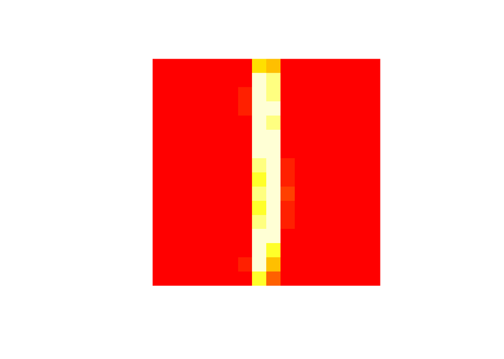

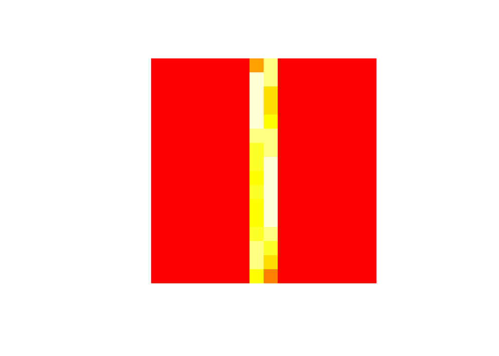

```r
images <- lapply(idx(1)[1:4], function(i) image(digitMatrix(i), axes=F, asp=1))
```

First four 3’s:

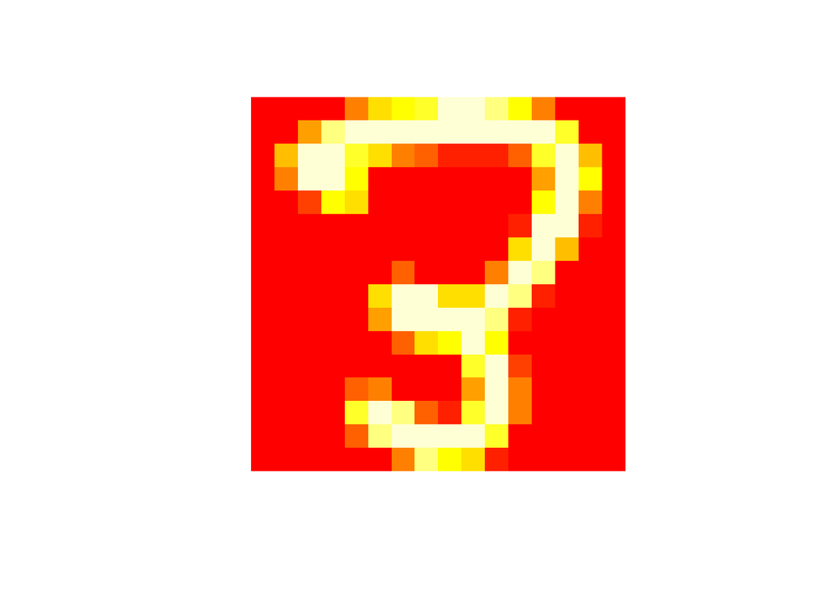

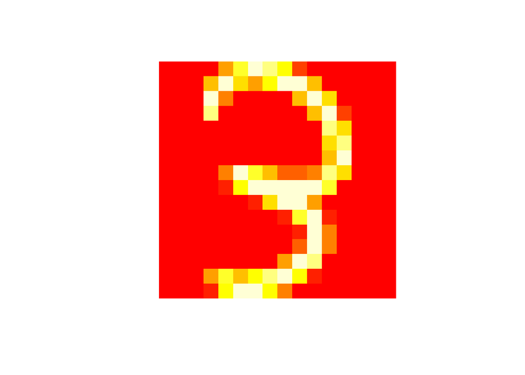

[figure not shown]

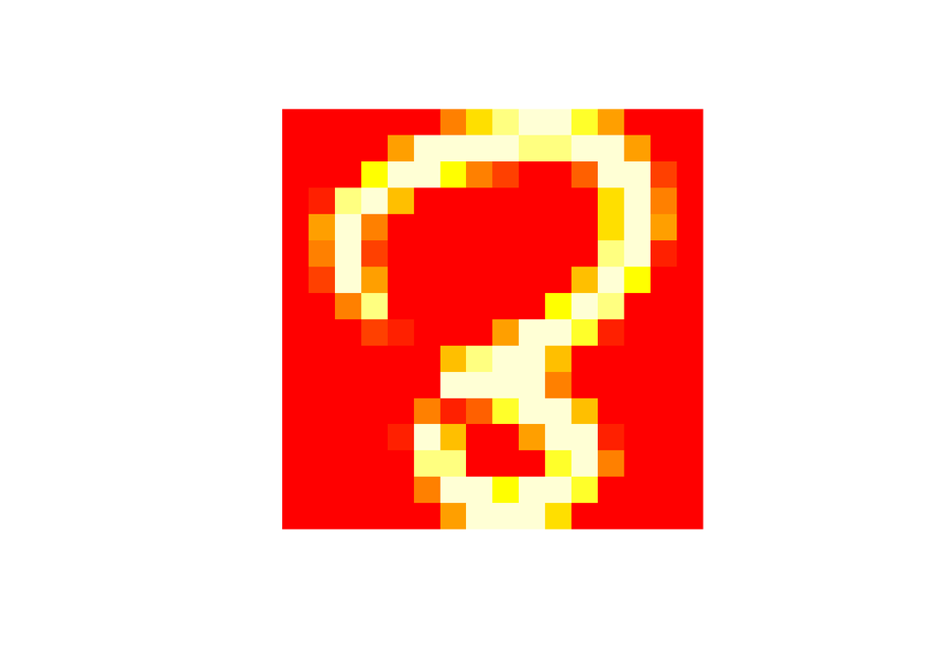

```r
images <- lapply(idx(3)[1:4], function(i) image(digitMatrix(i), axes=F, asp=1))
```

First four 5’s:

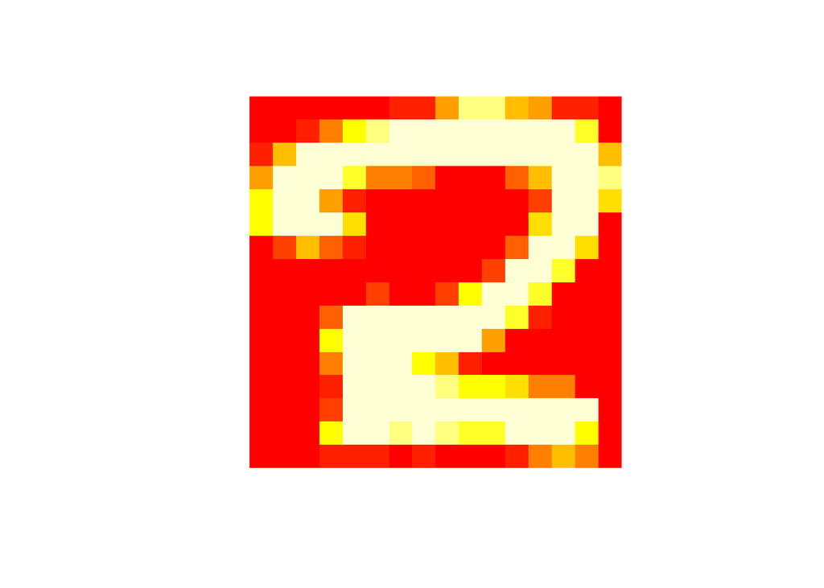

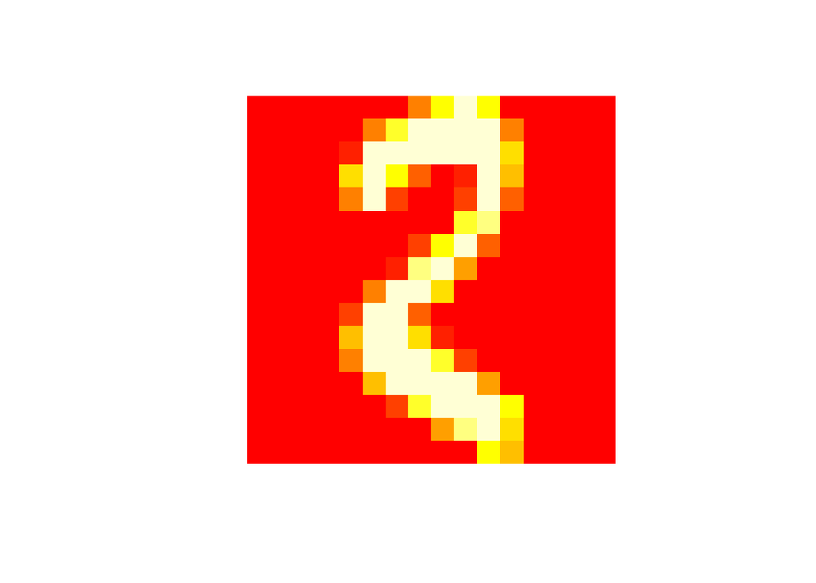

[figure not shown]

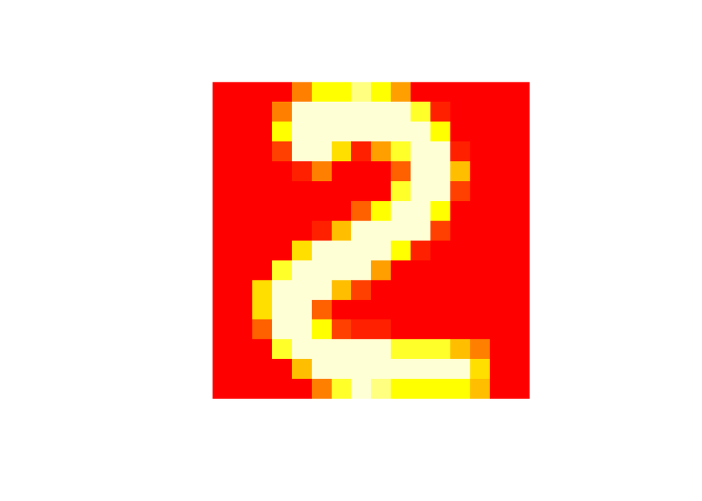

```r
images <- lapply(idx(5)[1:4], function(i) image(digitMatrix(i), axes=F, asp=1))
```

### 1.4

Show digit in the right direction and in grayscale:

```r
showDigit <- function(mat) {
  image(-mat[, ncol(mat):1], axes=F, asp=1, col=grey(seq(0,1,length=256)))
}
```

First four 1’s:

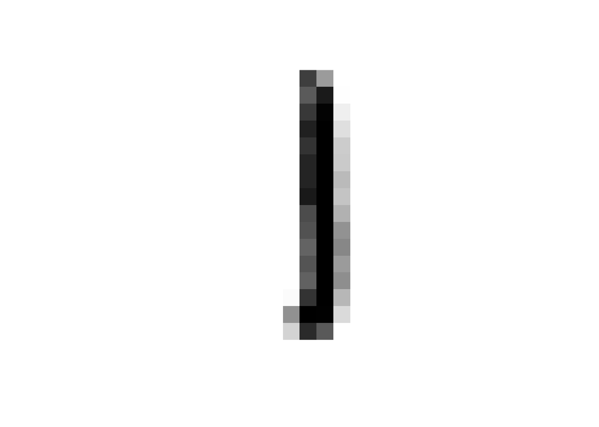

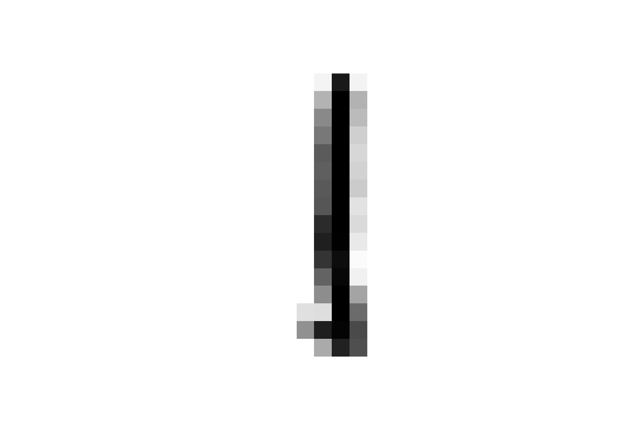

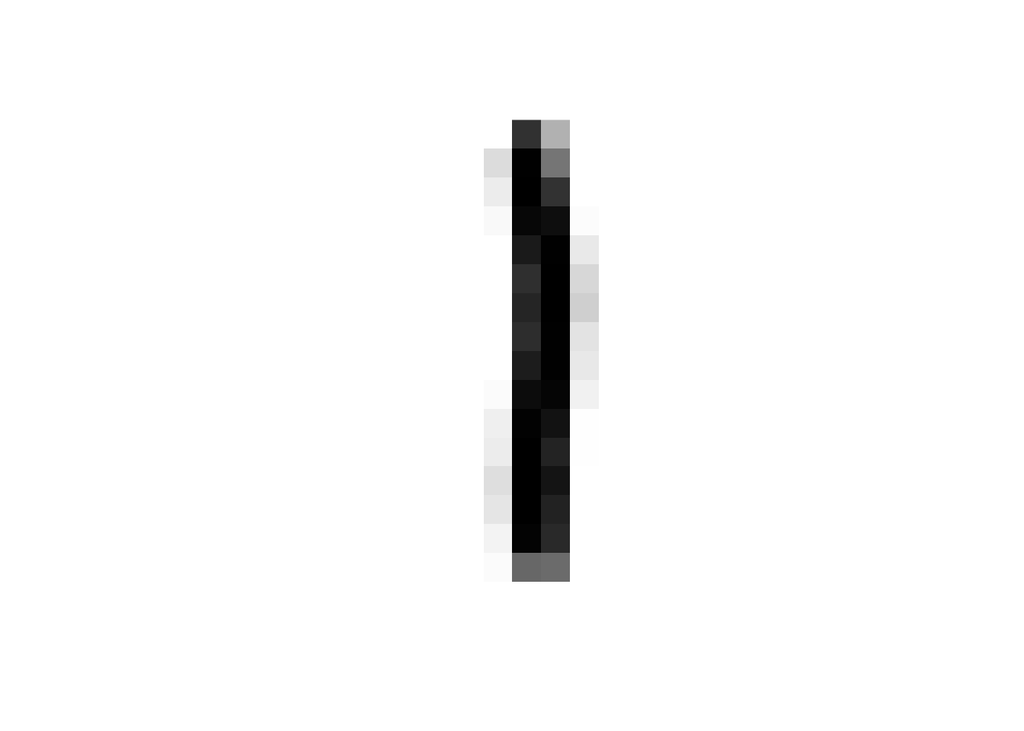

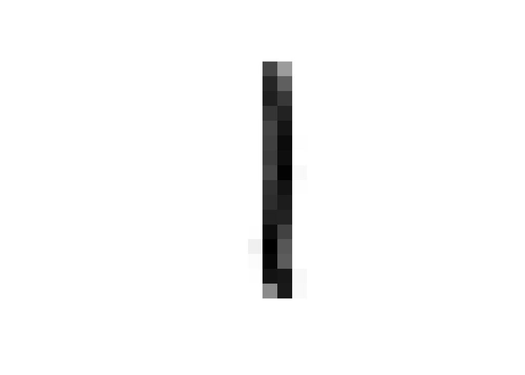

```r
images <- lapply(idx(1)[1:4], function(i) showDigit(digitMatrix(i)))
```

First four 3’s:

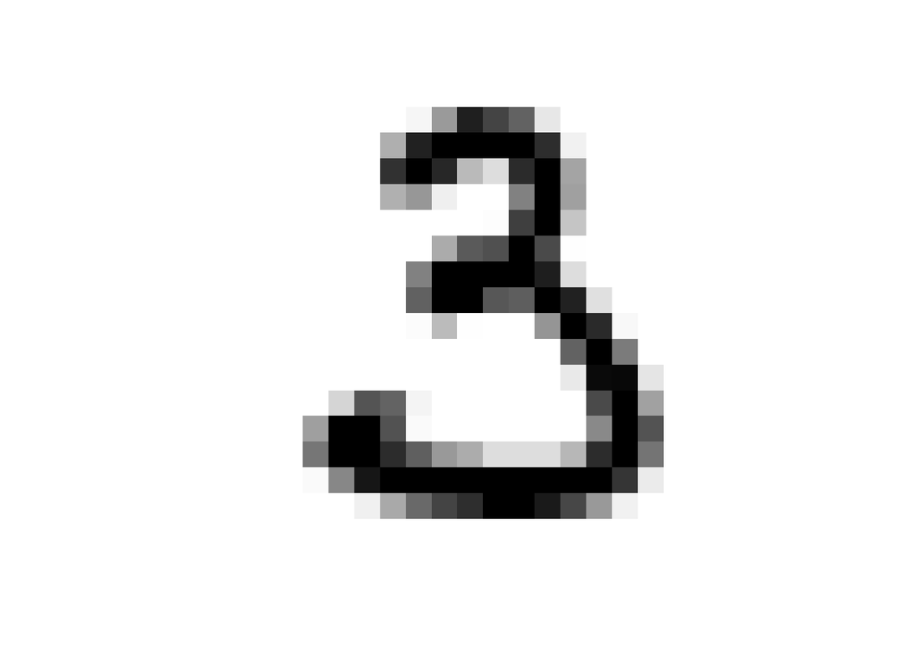

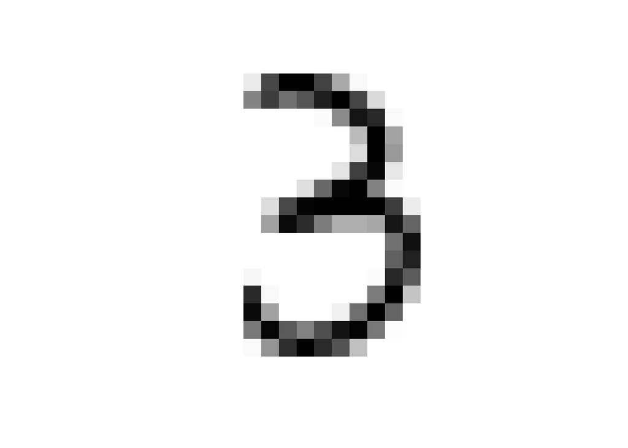

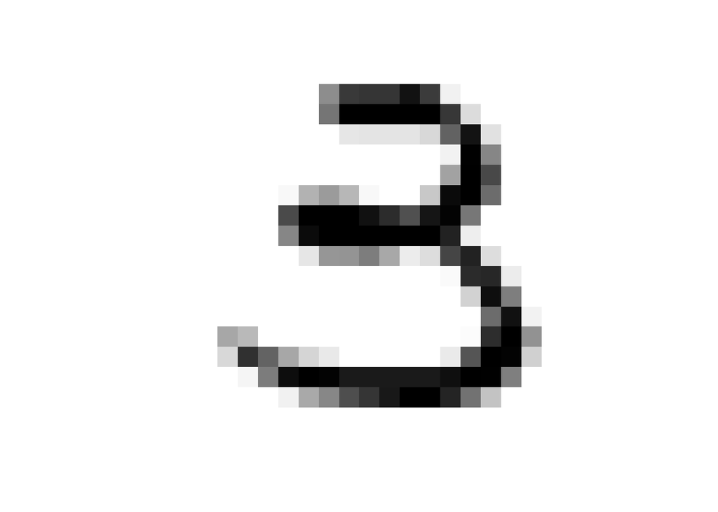

[figure not shown]

```r
images <- lapply(idx(3)[1:4], function(i) showDigit(digitMatrix(i)))
```

First four 5’s:

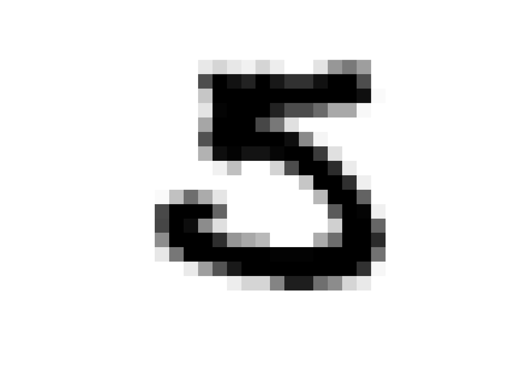

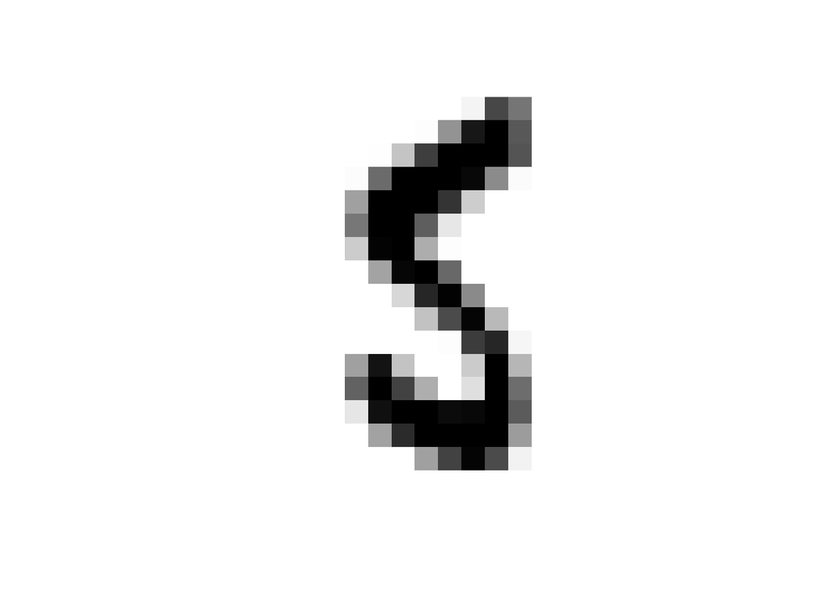

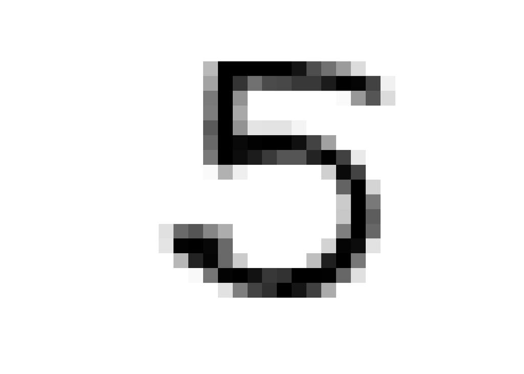

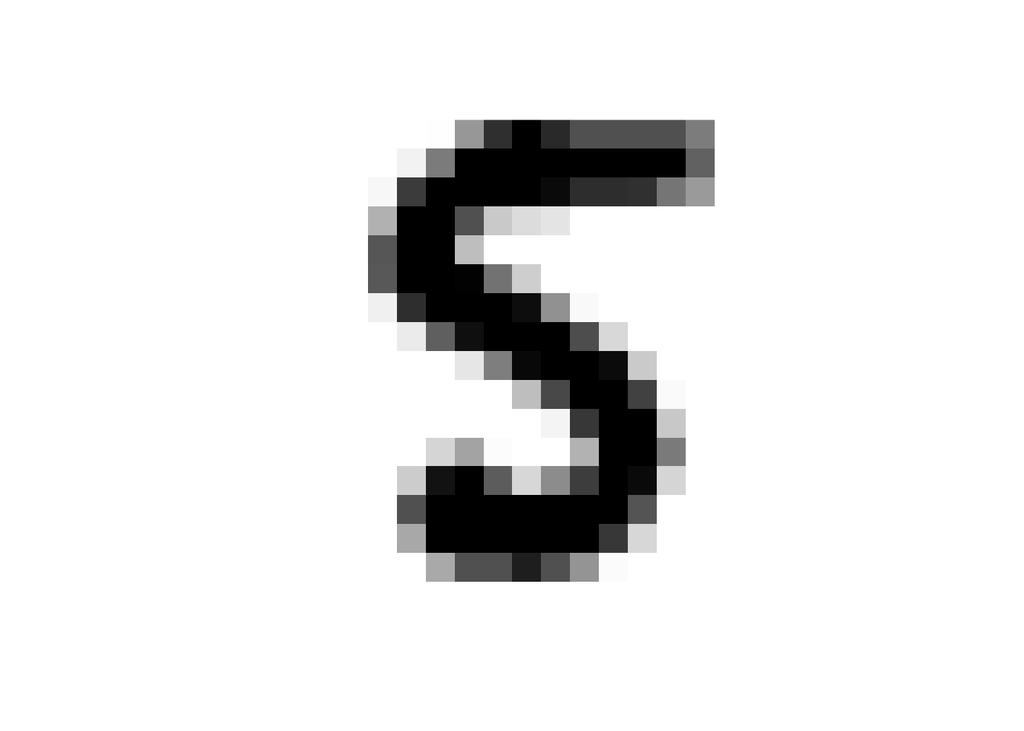

```r
images <- lapply(idx(5)[1:4], function(i) showDigit(digitMatrix(i)))
```

## Problem 3

### 3.1

Read the microarray dataset:

```r
library(dplyr)
dat <- read.table("../HW01/microarray.txt", head=TRUE)
dat <- dat %>% select(starts_with("LEUKEMIA"), starts_with("MELANOMA"))
```

Do PCA based on covariance:

```r
dat.pca <-prcomp(t(as.matrix(dat)), scale.=F)
```

### 3.2

Plot barplot of the eigenvalues:

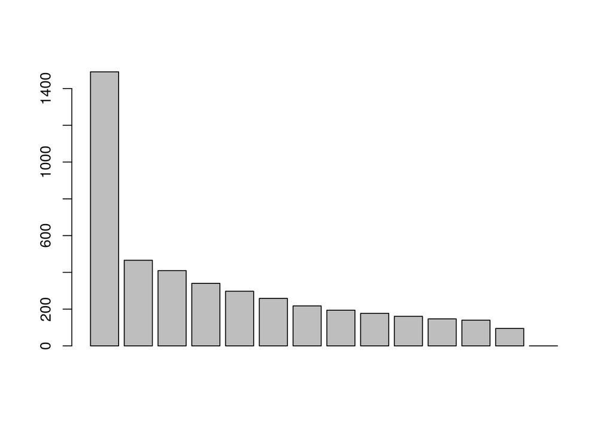

```r
barplot(dat.pca$sdev^2)
```

Here we could keep only one pricincipal component since the bar plot tends to level off (an “elbow” is shown) after the first component.

Proportion of variances kept in the first n principal components:

```r
cumsum(dat.pca$sdev^2) / sum(dat.pca$sdev^2)
```

```
##  [1] 0.3392624 0.4452642 0.5384686 0.6158872 0.6835434 0.7423331 0.7918571
##  [8] 0.8360817 0.8763869 0.9130277 0.9464924 0.9783690 1.0000000 1.0000000
```

### 3.3

Three genes that contribute most to the first principal component positively:

```r
pc1 <- dat.pca$rotation[,1]
which(pc1 >= sort(pc1, decreasing=T)[3])
```

```
## [1] 4244 4353 4354
```

Three genes that contribute most to the first principal component negatively:

```r
which(pc1 <= sort(pc1, decreasing=F)[3])
```

```
## [1] 2080 2081 2082
```

### 3.4

Plot projection of the datset on the first two principal components. The samples are well-separated.

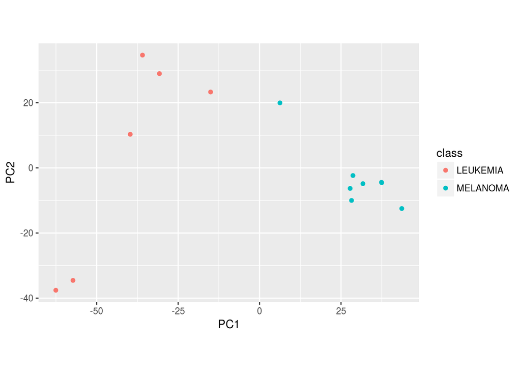

```r
library(ggplot2)
ggplot(as.data.frame(dat.pca$x[,1:2]), aes(PC1, PC2, color=sapply(names(dat), function(c) gsub("\\.\\d", "", c)))) +
  geom_point() + coord_fixed() + guides(color=guide_legend(title="class"))
```

## Problem 4

### 4.1

Read the data:

```r
dat <- readRDS(file="zip.RData")
```

Do PCA based on covariance:

```r
dat.pca <-prcomp(as.matrix(dat$train[,-1]), scale.=F)
```

### 4.2

Plot projection of the datset on the first two principal components. The 1’s are well-separated in this space. However, 3’s and 5’s are only partially separated.

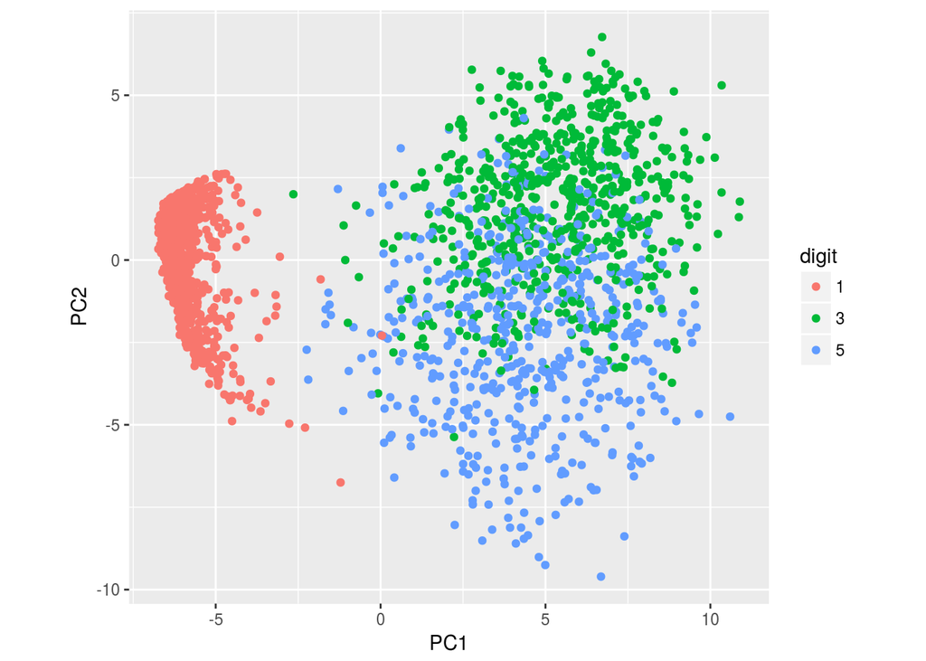

```r
ggplot(as.data.frame(dat.pca$x[,1:2]), aes(PC1, PC2, color=dat$train[,1])) +
  geom_point() + coord_fixed() + guides(color=guide_legend(title="digit"))
```

### 4.3

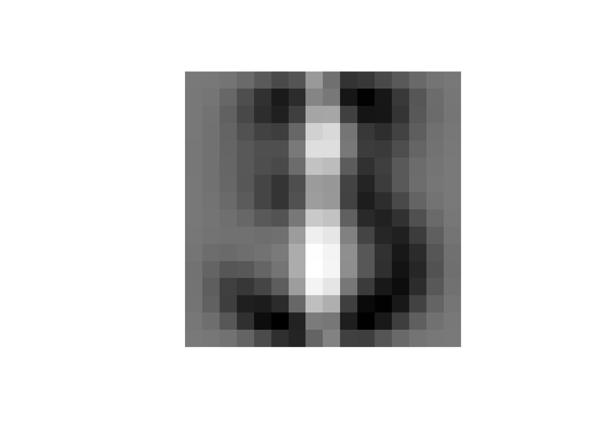

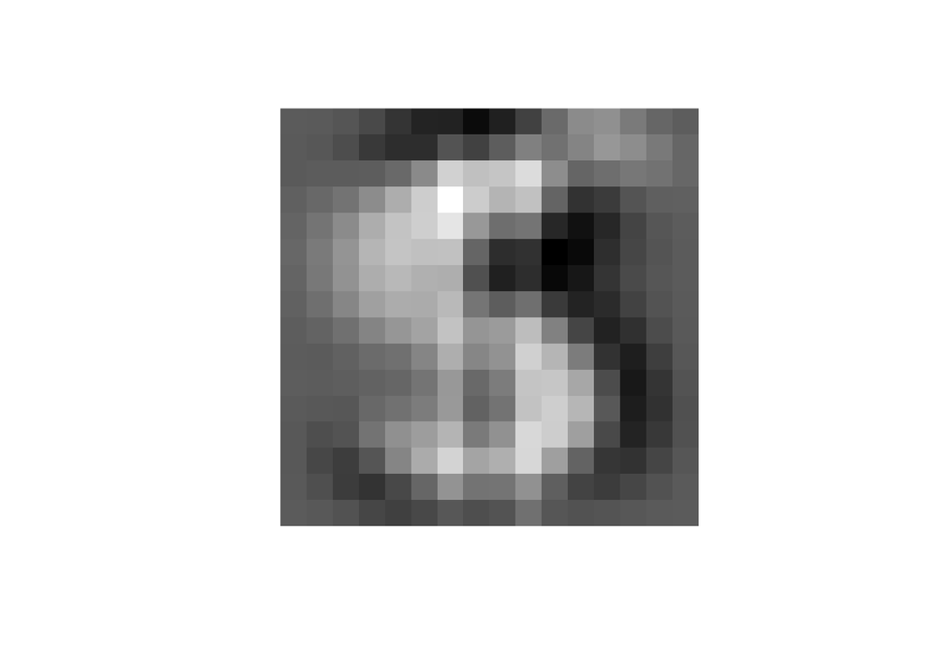

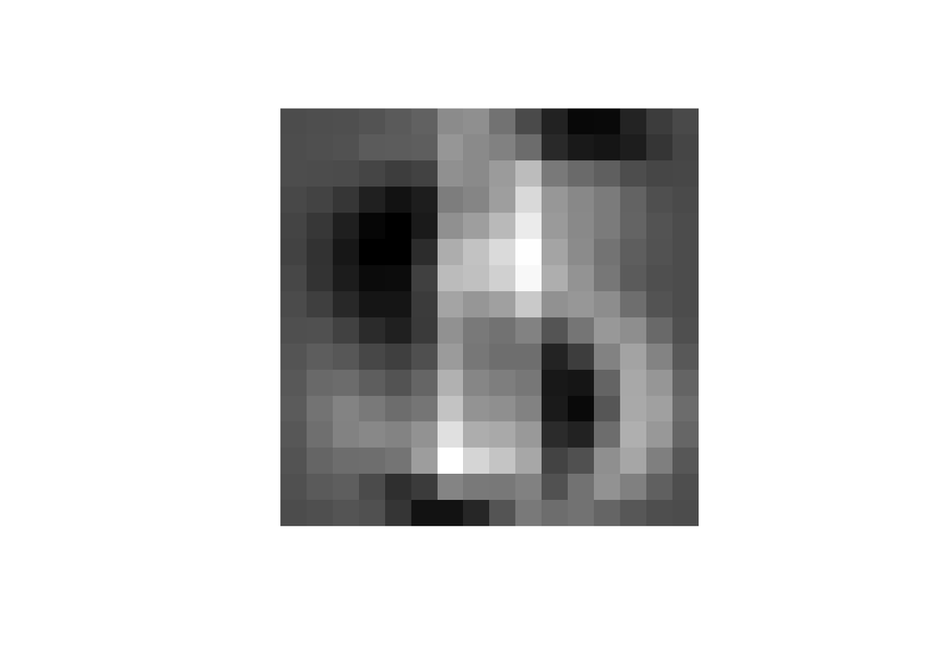

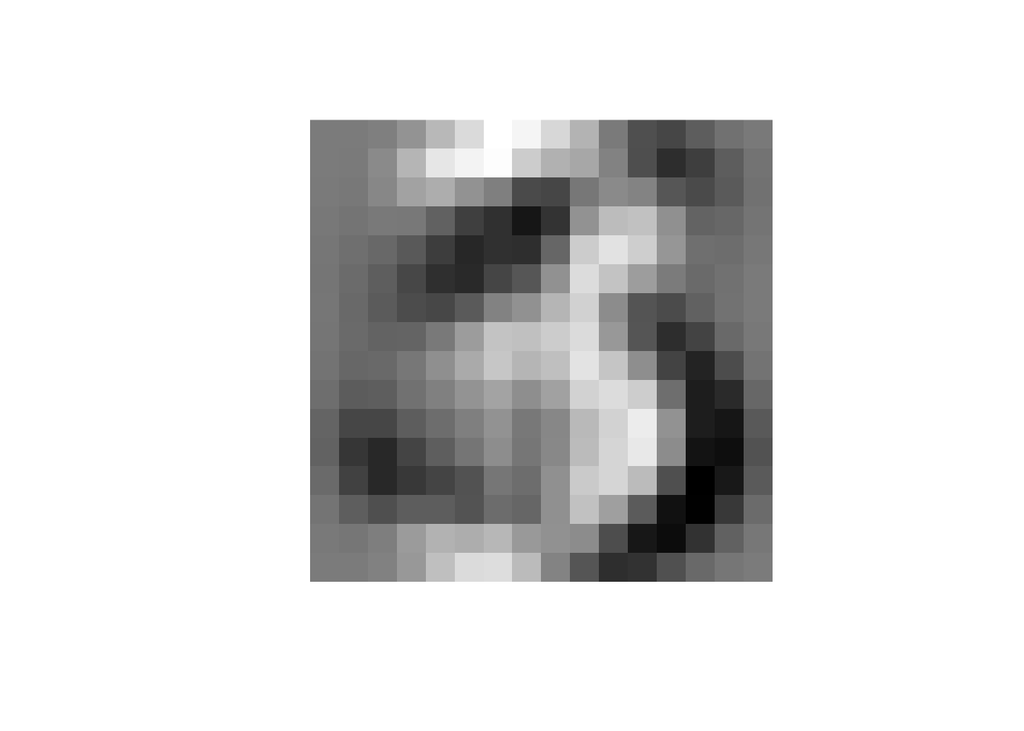

```r
images <- lapply(1:4, function(i) showDigit(matrix(dat.pca$rotation[,i], nrow=16, ncol=16)))
```

### 4.4

We see that the first principal component direction well-distinguished 1’s (light colors in the figure), which separated 1’s from 3’s and 5’s. And then the second principal component was used to distinguish 5’s and 3’s (light colors for 5, dark colors for 3).